# Mapping a Redux Store with R

2017-04-13T21:48:51-07:00

For the past few years I’ve been working on a meditation app first as a project manager and now as a developer. The app came about because a lot of the meditation apps are built for introductory meditators. They tend to be focused around audio instructions for people new to the practice, and the timers tend to be designed to time set intervals of time.

Shambhala has a lot of quite seasoned meditators, and they often do complicated meditation practices. So you might have a period of meditation which is separated into a few different sections which are irregularly timed. For instance you might break a 45 minute meditation session into a 6 minute section, two 15 minute secions and an 8 minute segment at the end. The idea behind the Shambhala app was to create a kind of modular framework which allows people to create very complex timers out of simple bits. The three build blocks for a timer are time intervals, gong sounds, and recorded audio contemplations, and the user can stack these building blocks to create whatever kind of meditation session they want.

While I think the basic idea of the initial app was a good one, the implementation was a bit of a mess. The user interface was confusing and there were a lot of counter-intuitive design decisions. Since I was the source of many of these decisions, I thought the release of version 2.0 of the app would be a good opportunity to write down some of the things I’ve learned.

I started programming in R because I was interested in data visualization best practices, and what I’ve noticed working on the Shambhala App is how much overlap there is between data vizualisation and user interface design. In particular there are three slogans that I’ve found useful for both problems:

This is a slight restatement of one of Edward Tufte’s famous data visualiztion principles. The idea is that you should aim to be as efficient as possible with how much space you use to present your data. If you are selecting between different ways of displaying data, the best bet is to select the one which uses the least ink. This principle tends to pull you towards using lighter shapes to express data. For instance these two charts show the same information, but from a Tuftean perspective the one on the left is better because it displays the same information with less ink.

The way this principle applies to UI design is to be efficient with the visual attention of your user. The user only has so much time and attention to devote to your application and they tend to like applications which don’t waste that attention. If you can convey the same amount of information with fewer visual items, then that will tend to improve the user experience.

```r
library(tidyverse)
```

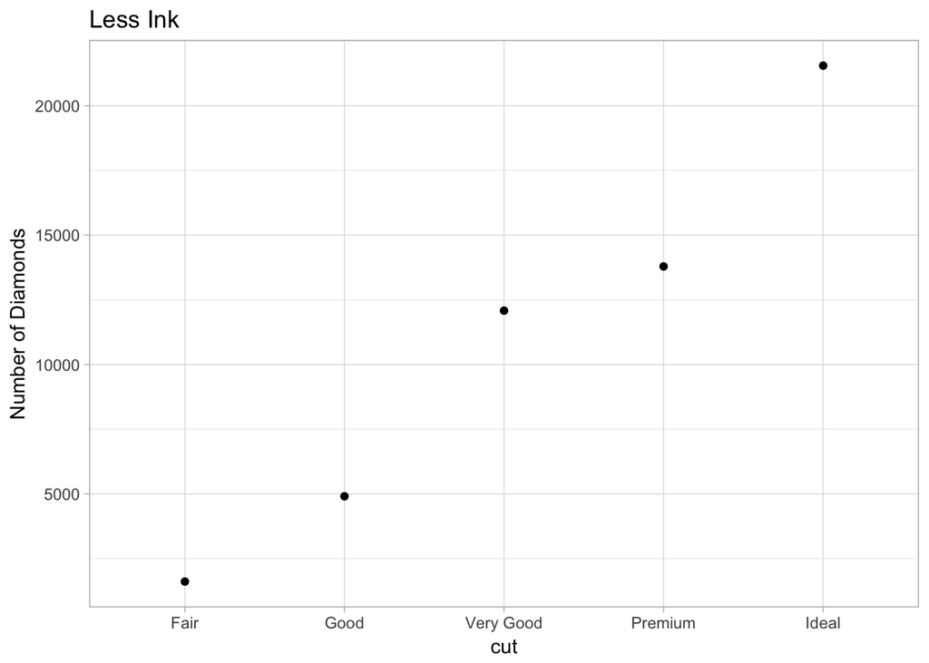

```r
library(forcats)
library(nycflights13)

diamonds %>%
  group_by(cut) %>%
  tally() %>%
  ggplot(aes(x = cut, y = n))+
  geom_point()+
  ylab("Number of Diamonds") +
  ggtitle("Less Ink")+
  theme_light()
```

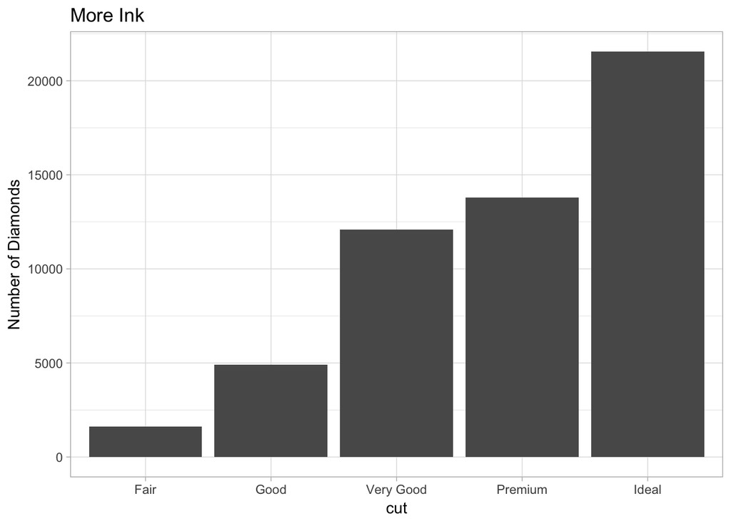

```r
diamonds %>%
  ggplot(aes(x = cut))+
  geom_bar()+
  ylab("Number of Diamonds") +
  ggtitle("More Ink")+
  theme_light()
```

3. Make us of Idioms

Idioms are bits of language whose meaning derive mostly from their use rather than their content. For instance the phrase “It’s a piece of cake” is pretty confusing when read literally, but communicates quite a lot because of how it’s typically used. The same is true in visual communication. People get used to certain shapes representing certain types of information, and it’s often better to go along with those preconceptions rather than trying to change them. For instance, the bar chart above is less efficient at communicating the data, but people tend to associate bar charts with counts, and so it’s often a good choice when you are communicating counts of a categorical variable.

In user interface design, this principle implies that you should pick your battles in terms of creating new visual forms. Make your buttons look like buttons, and your forms look like forms. A bad UI artifact that your user already understands is usually better than a great one that they need to learn.